# Big Five Personality Analysis

## Model diagnostics

Model comparison favored Model 2, so we next examined whether its assumptions appeared reasonable before interpreting its coefficients.

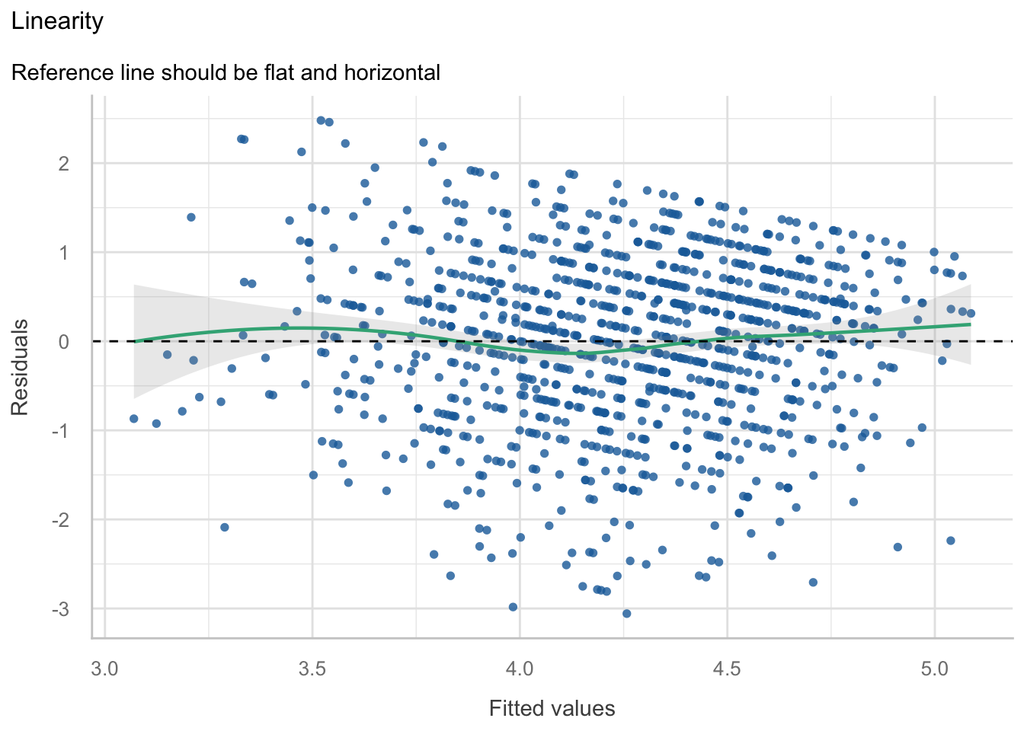

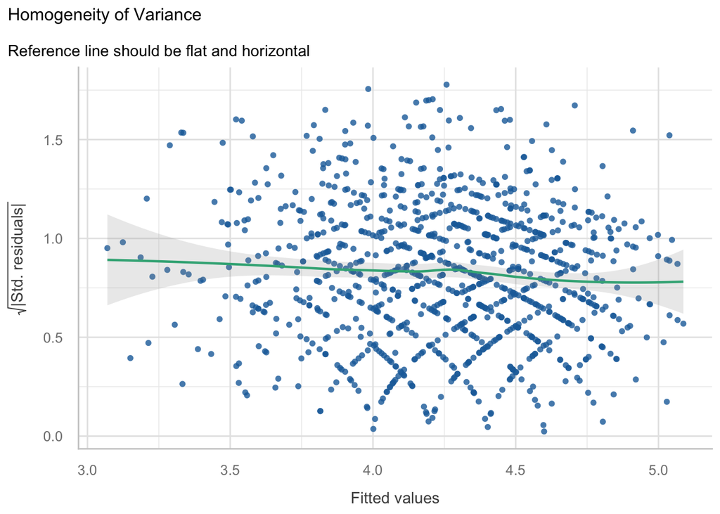

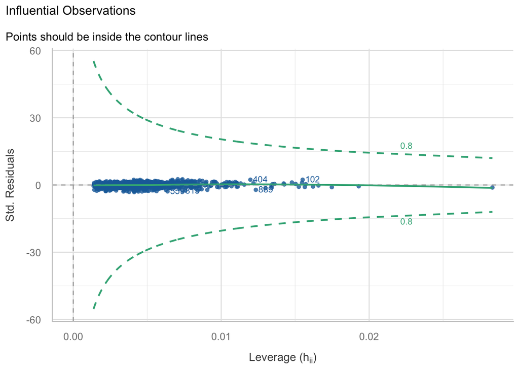

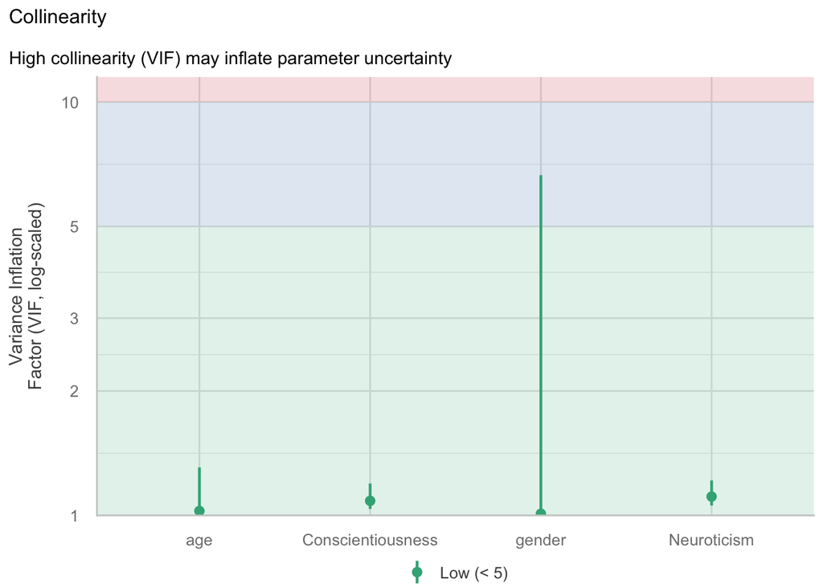

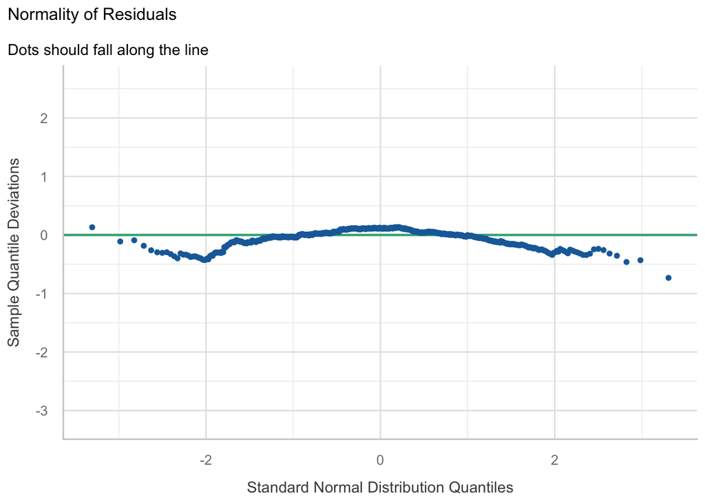

```r
#| label: model-diagnostics
#| fig-width: 9
#| fig-height: 6
#| column: page

diagnostic_plots <- performance::check_model(
  model_2,
  check = c(
    "qq",
    "linearity",
    "homogeneity",
    "outliers",
    "vif"
  ),
  panel = FALSE,
  base_size = 13
)

plot(diagnostic_plots)
```

The diagnostic plots were examined for evidence of substantial violations of the assumptions underlying the linear regression model. In particular, we looked for strong departures from residual normality, systematic patterns in the residuals, non-constant residual variance, highly influential observations, and problematic collinearity among the predictors

## Final model

```r
#| label: final-model-table

final_model_table <- tidy(
  model_2,
  conf.int = TRUE,
  conf.level = .95
) |>
  mutate(
    term = recode(
      term,
      `(Intercept)` = "Intercept",
      age = "Age",
      genderFemale = "Gender: Female",
      Neuroticism = "Neuroticism",
      Conscientiousness = "Conscientiousness"
    ),
    # Format p-values for presentation
    p = case_when(
      p.value < .001 ~ "< .001",
      TRUE ~ sprintf("%.3f", p.value)
    )
  )

final_model_table |>
  select(
    term,
    estimate,
    std.error,
    statistic,
    conf.low,
    conf.high,
    p
  ) |>
  gt() |>
  tab_header(
    title = "Linear Regression Predicting Extraversion",
    subtitle = paste0(
      "N = ", nobs(model_2),
      "; R² = ", round(glance(model_2)$r.squared, 3)
    )
  ) |>
  cols_label(
    term = "Predictor",
    estimate = "b",
    std.error = "SE",
    statistic = "t",
    conf.low = "95% CI Low",
    conf.high = "95% CI High",
    p = "p"
  ) |>
  fmt_number(
    columns = c(
      estimate,
      std.error,
      statistic,
      conf.low,
      conf.high
    ),
    decimals = 2
  ) |>
  opt_row_striping()
```

Linear Regression Predicting Extraversion

N = 1044; R² = 0.126

| Predictor | b | SE | t | 95% CI Low | 95% CI High | p |
| --- | --- | --- | --- | --- | --- | --- |
| Intercept | 4.16 | 0.25 | 16.73 | 3.67 | 4.65 | < .001 |
| Age | −0.01 | 0.00 | −2.75 | −0.02 | 0.00 | 0.006 |
| Gender: Female | 0.30 | 0.07 | 4.56 | 0.17 | 0.43 | < .001 |
| Neuroticism | −0.20 | 0.03 | −7.68 | −0.25 | −0.15 | < .001 |
| Conscientiousness | 0.20 | 0.03 | 5.88 | 0.13 | 0.26 | < .001 |

# Discussion

Look at those results! Incredible!